# FitBit Analysis

## The Problem

The problem or the general question of this analysis is to figure out the latest trends in smart device usage in general. Then figure out how these relate the company and how Bellabeat, a smart device company could use these insights to direct it’s marketing strategy.

## Key Stakeholders

- Urška Sršen the Chief Creative Executive.
- Sando Mur Co-founder and Mathematician

## Preparation and Proccessing of the datasets

# Analysis

## Introduction

This is the analysis of the data set using R. Below will be the thought process and the code to execute and answer the question and gain insight.

Start by loading all the packages I might need in the processing of the data set.

```r
library(ggplot2)
library(tidyverse)
library(plyr)
library(dplyr)
```

## Datasets

The next thing will be to import the data sets I will be working with. First one being the daily activity

```r
daily_activity <- read.csv("dailyActivity_merged.csv")
```

Followed by the sleep data.

```r
sleep_day <- read.csv("sleepDay_merged.csv")
```

Next, explore the 2 files a bit, see how they look like.

```r
head(daily_activity)
```

```
##           Id ActivityDate TotalSteps TotalDistance TrackerDistance
## 1 1503960366    4/12/2016      13162          8.50            8.50
## 2 1503960366    4/13/2016      10735          6.97            6.97
## 3 1503960366    4/14/2016      10460          6.74            6.74
## 4 1503960366    4/15/2016       9762          6.28            6.28
## 5 1503960366    4/16/2016      12669          8.16            8.16
## 6 1503960366    4/17/2016       9705          6.48            6.48
##   LoggedActivitiesDistance VeryActiveDistance ModeratelyActiveDistance
## 1                        0               1.88                     0.55
## 2                        0               1.57                     0.69
## 3                        0               2.44                     0.40
## 4                        0               2.14                     1.26
## 5                        0               2.71                     0.41
## 6                        0               3.19                     0.78
##   LightActiveDistance SedentaryActiveDistance VeryActiveMinutes
## 1                6.06                       0                25
## 2                4.71                       0                21
## 3                3.91                       0                30
## 4                2.83                       0                29
## 5                5.04                       0                36
## 6                2.51                       0                38
##   FairlyActiveMinutes LightlyActiveMinutes SedentaryMinutes Calories
## 1                  13                  328              728     1985
## 2                  19                  217              776     1797
## 3                  11                  181             1218     1776
## 4                  34                  209              726     1745
## 5                  10                  221              773     1863
## 6                  20                  164              539     1728
```

Get the column names..

```r
colnames(daily_activity)
```

```
##  [1] "Id"                       "ActivityDate"
##  [3] "TotalSteps"               "TotalDistance"
##  [5] "TrackerDistance"          "LoggedActivitiesDistance"
##  [7] "VeryActiveDistance"       "ModeratelyActiveDistance"
##  [9] "LightActiveDistance"      "SedentaryActiveDistance"
## [11] "VeryActiveMinutes"        "FairlyActiveMinutes"
## [13] "LightlyActiveMinutes"     "SedentaryMinutes"
## [15] "Calories"
```

…then sleep data;

```r
head(sleep_day)
```

```
##           Id              SleepDay TotalSleepRecords TotalMinutesAsleep
## 1 1503960366 4/12/2016 12:00:00 AM                 1                327
## 2 1503960366 4/13/2016 12:00:00 AM                 2                384
## 3 1503960366 4/15/2016 12:00:00 AM                 1                412
## 4 1503960366 4/16/2016 12:00:00 AM                 2                340
## 5 1503960366 4/17/2016 12:00:00 AM                 1                700
## 6 1503960366 4/19/2016 12:00:00 AM                 1                304
##   TotalTimeInBed
## 1            346
## 2            407
## 3            442
## 4            367
## 5            712
## 6            320
```

and the column names;

```r
colnames(sleep_day)
```

```
## [1] "Id"                 "SleepDay"           "TotalSleepRecords"
## [4] "TotalMinutesAsleep" "TotalTimeInBed"
```

## Diving into the data

First figure out how many participants are the in the datasets;

```r
n_distinct(daily_activity$Id)
```

```
## [1] 33
```

```r
n_distinct(sleep_day$Id)
```

```
## [1] 24
```

The results show we have 9 more participants in the daily activity dataset than in the sleep day data set.

Then we get the number of observations/rows for both data sets;

```r
nrow(daily_activity)
```

```
## [1] 856
```

```r
nrow(sleep_day)
```

```
## [1] 413
```

The daily activity data set has more than 2 times the number of observations as the sleep day data set.

Check the basic stats from the datasets, starting with the daily activity dataset;

```r
daily_activity %>%
  select(TotalSteps,
         TotalDistance,
         SedentaryMinutes) %>%
  summary()
```

```
##    TotalSteps    TotalDistance    SedentaryMinutes
##  Min.   :    0   Min.   : 0.000   Min.   : 125.0
##  1st Qu.: 4924   1st Qu.: 3.370   1st Qu.: 721.8
##  Median : 8054   Median : 5.590   Median :1020.0
##  Mean   : 8328   Mean   : 5.983   Mean   : 955.4
##  3rd Qu.:11100   3rd Qu.: 7.912   3rd Qu.:1188.0
##  Max.   :36019   Max.   :28.030   Max.   :1439.0
```

Already from this summary, there is one thing that is clear, there is a huge gap between the average number of steps(mean) and the maximum number of steps, same goes for the total distance.

Then to the sleep day data set;

```r
sleep_day %>%
  select(TotalSleepRecords,
  TotalMinutesAsleep,
  TotalTimeInBed) %>%
  summary()
```

```
##  TotalSleepRecords TotalMinutesAsleep TotalTimeInBed
##  Min.   :1.000     Min.   : 58.0      Min.   : 61.0
##  1st Qu.:1.000     1st Qu.:361.0      1st Qu.:403.0
##  Median :1.000     Median :433.0      Median :463.0
##  Mean   :1.119     Mean   :419.5      Mean   :458.6
##  3rd Qu.:1.000     3rd Qu.:490.0      3rd Qu.:526.0
##  Max.   :3.000     Max.   :796.0      Max.   :961.0
```

There are sleep hours which are questionable, like the 796 minutes, do they indicate sick days, should there be a system to notify a parent, spouse, doctor or a caretaker if there is ever such an unusual activity.

To get a better insight, we need to plot some graphs.

## Plotting some graphs

Lets first check the relationship between the number of steps taken and the sedentary minutes. Hypothesis, the more steps you are taking the less sedentary minutes.

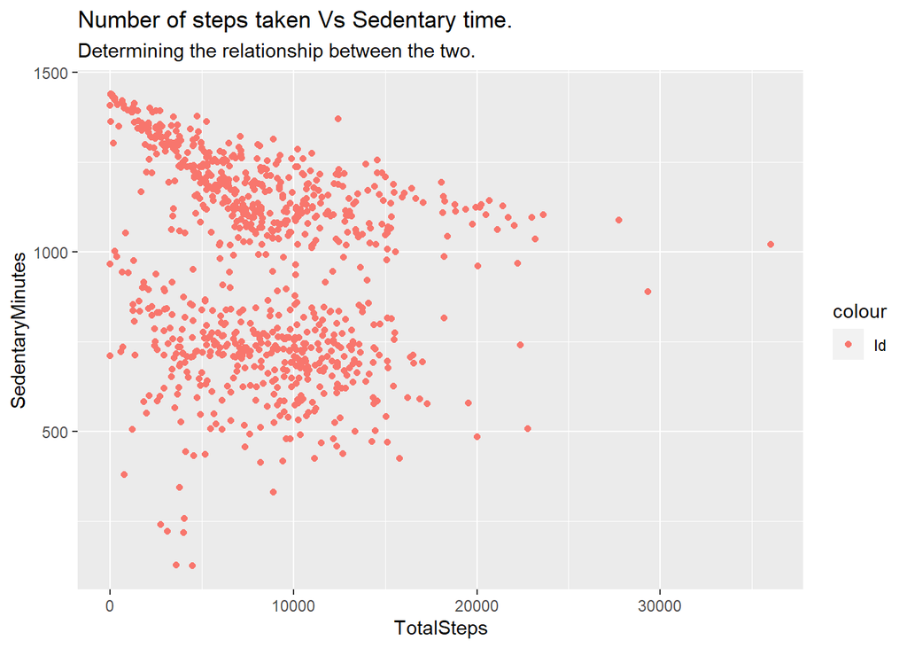

```r
ggplot(data=daily_activity, aes(x=TotalSteps, y=SedentaryMinutes, color = "Id")) + geom_point() +labs(title = "Number of steps taken Vs Sedentary time.", subtitle = "Determining the relationship between the two.")
```

Take away from the graph… The two are negatively correlated as one might guess, if someone is spending more time being inactive, you can expect they will have fewer steps than someone who is more active. How does this help us? Are the other activities either than taking that should be tracked.

Next, minutes in bed vs the total minutes asleep

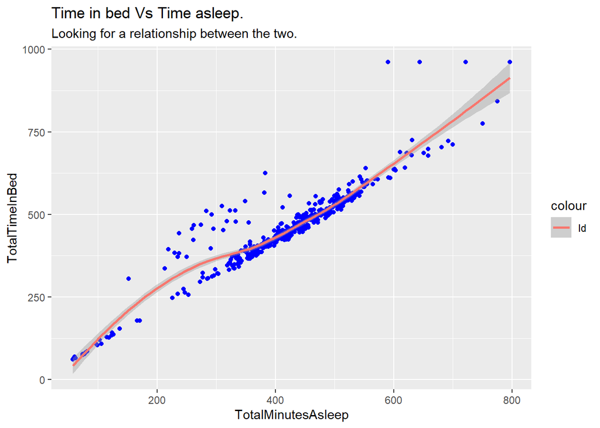

```r
ggplot(data=sleep_day, aes(x=TotalMinutesAsleep, y=TotalTimeInBed, color = "Id")) + geom_point(color= "blue")+ geom_smooth() + labs(title = "Time in bed Vs Time asleep.", subtitle = "Looking for a relationship between the two.")
```

```r
cor(sleep_day$TotalMinutesAsleep, sleep_day$TotalMinutesAsleep ,method = "pearson")
```

```
## [1] 1
```

Almost perfectly linear relationship, some outliers though, hard to ignore, what could it mean? It might be that they struggle to sleep, are they having enough activity? Users like these, if they have made their information available to the company, could be offered program in the membership subscription to help with their inability to sleep or underlying problem.

What could these trends tell you about how to help market this product? Or areas where you might want to explore further?

## Merge the two datasets

```r
combined_data <- merge(sleep_day, daily_activity, by="Id")
```

Check the number of participants, if not 24, there will be a need to adjust the code

```r
n_distinct(combined_data$Id)
```

```
## [1] 24
```

There are equal number of Ids.

Next will be to look for relationships in this data, first will be the number of steps compared to the sleep time on a given day. I am expecting that when one takes more steps they will get better/more sleep, let’s see if this is the case.

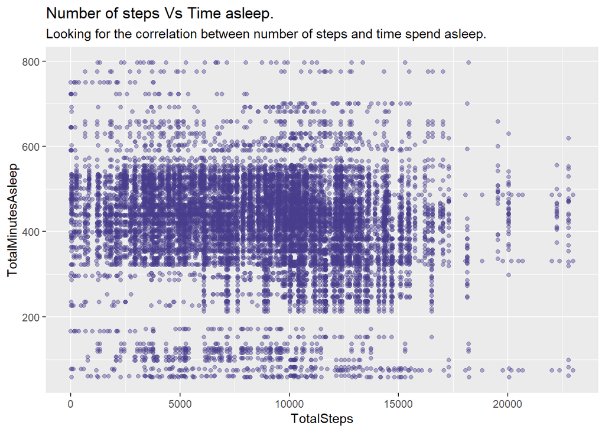

```r
ggplot(data=combined_data, aes(x=TotalSteps, y=TotalMinutesAsleep)) + geom_point(color="slateblue4",alpha = 0.4)+ labs(title= "Number of steps Vs Time asleep.", subtitle = "Looking for the correlation between number of steps and time spend asleep.")
```

Most people seem to have about the same amount of sleep time regardless of the number of steps taken, that is the dominant trend.

```r
cor(combined_data$TotalMinutesAsleep, combined_data$TotalSteps ,method = "pearson")
```

```
## [1] -0.1106412
```

A weak negative correlation exists, bottom line, most people sleep for 6-8 hour regardless of activity on a given day.

I am now curious about sedentary minutes vs sleep time.

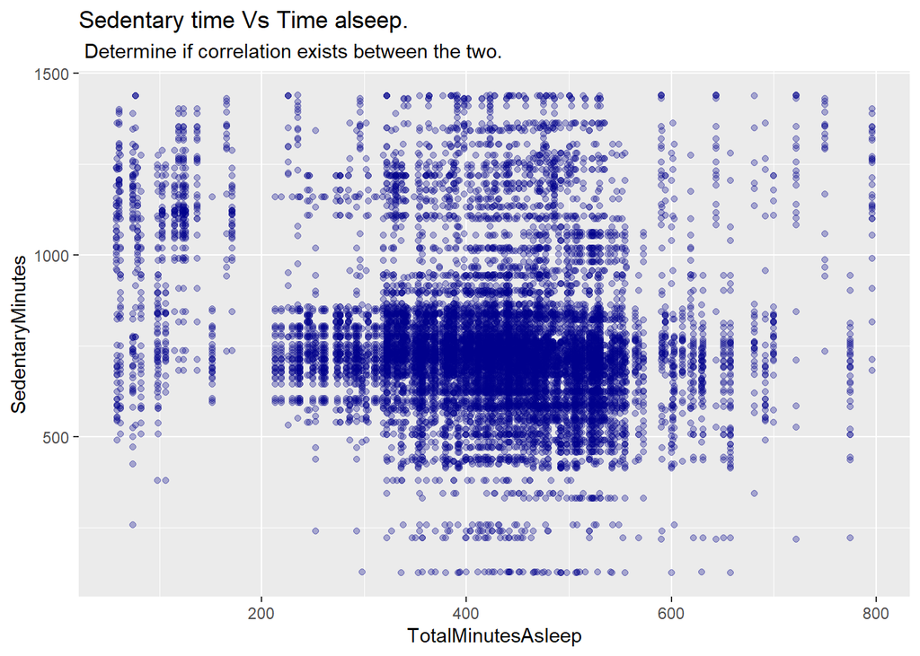

```r
ggplot(data=combined_data, aes(x=TotalMinutesAsleep, y=SedentaryMinutes)) + geom_point(color = "darkblue", alpha = 0.3) + labs(title = "Sedentary time Vs Time alseep.", subtitle = " Determine if correlation exists between the two.")
```

```r
cor(combined_data$SedentaryMinutes, combined_data$TotalSteps ,method = "pearson")
```

```
## [1] -0.2024329
```

## Import more files

At this point, one is shooting darts, seeing if there’s anything that catches my eye.

```r
daily_calories <- read.csv("dailyCalories_merged.csv")
```

```r
head(daily_calories)
```

```
##           Id ActivityDay Calories
## 1 1503960366   4/12/2016     1985
## 2 1503960366   4/13/2016     1797
## 3 1503960366   4/14/2016     1776
## 4 1503960366   4/15/2016     1745
## 5 1503960366   4/16/2016     1863
## 6 1503960366   4/17/2016     1728
```

```r
n_distinct(daily_calories$Id)
```

```
## [1] 33
```

```r
combined_with_calories <- merge(combined_data, daily_calories, by="Id")
```

```r
n_distinct(combined_with_calories$Id)
```

```
## [1] 24
```

```r
head(combined_with_calories)
```

```
##           Id              SleepDay TotalSleepRecords TotalMinutesAsleep
## 1 1503960366 4/12/2016 12:00:00 AM                 1                327
## 2 1503960366 4/12/2016 12:00:00 AM                 1                327
## 3 1503960366 4/12/2016 12:00:00 AM                 1                327
## 4 1503960366 4/12/2016 12:00:00 AM                 1                327
## 5 1503960366 4/12/2016 12:00:00 AM                 1                327
## 6 1503960366 4/12/2016 12:00:00 AM                 1                327
##   TotalTimeInBed ActivityDate TotalSteps TotalDistance TrackerDistance
## 1            346    4/22/2016      12764          8.13            8.13
## 2            346    4/22/2016      12764          8.13            8.13
## 3            346    4/22/2016      12764          8.13            8.13
## 4            346    4/22/2016      12764          8.13            8.13
## 5            346    4/22/2016      12764          8.13            8.13
## 6            346    4/22/2016      12764          8.13            8.13
##   LoggedActivitiesDistance VeryActiveDistance ModeratelyActiveDistance
```

[output cut: 27 more lines]

The hypothesis here is that the more steps the more calories burnt.

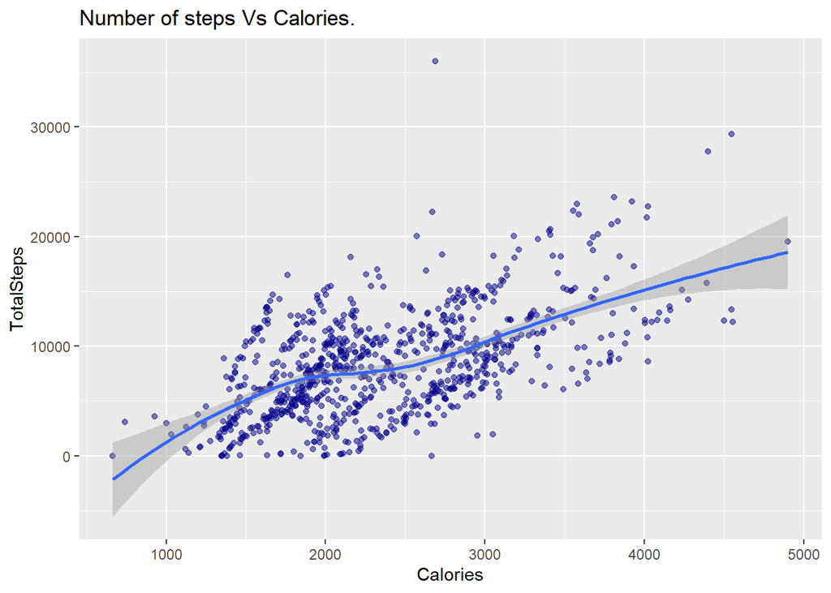

```r
ggplot(data= daily_activity, aes(x=Calories, y=TotalSteps)) + geom_point(color = "darkblue", alpha=0.5) + geom_smooth()+ labs(title = "Number of steps Vs Calories.", "Checking the correlation between the two.")
```

```r
cor(daily_activity$Calories, daily_activity$TotalSteps ,method = "pearson")
```

```
## [1] 0.5585717
```

A positive correlation, moderately strong.

# Conclusion and Recommendations

One can continue to import a lot more other datasets to analyse, but it is clear as day what people use their smart devices for and there is no insight to be gained in this regard from further digging, given our main objective/question.

- People use their smart devices to better take care of their health, all these variables we have been measuring here are of utmost importance to owners of smart devices so they can make healthy life choices.
- The other apparent trend is that in a given group, there is a huge difference between the activity of participants, some are more active while others aren’t.

Now, to the most important question, how does this help and inform the markerting stratergy of Bellabeat?

- The first and most obvious is that Bellabeat is missing a product for a subset of their target that is above average active, commonly refered to as “sporty”, this means they need to design a product that is going to cater for this group, both in the design aesthetics and functionality. This is obviously long term and will require more time.

An easier to implement program to better promote their existing product line up is as follows;

- Introduce reward programs for people achieving their health goal.
- If someone wants to have reach a certain number of steps per day, wants to achieve a certain level of weight and all the other metrics, they can then be rewarded with points for hitting the targets, and these point, after they reach a certain number, can be used to grant them access to the membership subscription for a limited period.
- This will have an effect where there is a consistent use of the three products and a much better chance that people become subscribers after the trial period, a win win.